# Basics of GIS

**Authors:**

**Shammunul Islam (shais13irs@gmail.com)**

## 1. Basic data types in GIS

There are 2 basic types of geospatial data:

1. Vector data
2. Raster data

For vector data, there are 3 basic data types:

a. Point

b. LineString

c. Polygon

### Point data

```python
from shapely.geometry import Point
```

```python
p1 = Point(13, 27.21)
p1
```

The code is importing the Point class from the shapely.geometry module. The Point class is a geometric object that represents a point in 2D space with x and y coordinates.

Then, the code creates a new Point object named p1 by calling the Point constructor with the arguments (13, 27.21). This creates a point at the coordinates (13, 27.21) in 2D space.

Similarly, we can create a second or multiple points.

```python
p2 = Point(61, 56.21)
p2
```

```python
p3 = Point(30, -6.21)
p3
```

```python
p4 = Point(2, -30.21)
p4
```

### LineString

```python
from shapely.geometry import LineString
```

```python
line1 = LineString([p1, p2])
line1
```

The code creates a LineString object named line1 using the LineString class from the shapely.geometry module.

The LineString object represents a line in 2D space as a sequence of points. The LineString constructor takes a list of Point objects as its argument, so the code is passing a list containing two Point objects p1 and p2 as the argument to create a line segment connecting these two points.

```python
line2 = LineString([p1, p2, p3])
line2
```

### Polygon

```python
from shapely.geometry import Polygon
```

```python
Polygon([p1, p2, p3])
```

```python
Polygon([p1, p2, p3, p4])
```

We can have as many points as we need or want for polygons.

### Multipoints

**Example:** dataset of the locations of weather stations in Bangladesh.

In geospatial data analysis, the **MultiPoint** class in Python's **Shapely** library is used to represent collections of point objects in two-dimensional space. A **MultiPoint** object is a collection of one or more **Point** objects that are considered as a single entity.

```python
from shapely.geometry import MultiPoint, MultiLineString, MultiPolygon
```

```python
multip1 = MultiPoint([p1, p2, p3, p4])
multip1
```

### MultiLineString

The `MultiLineString` class in Python's Shapely library is used to represent collections of line objects in two-dimensional space. A `MultiLineString` object is a collection of one or more `LineString` objects that are considered as a single entity.

**Example:** dataset of roads in Dhaka.

### MultiPolygon

The **MultiPolygon** class in Python's Shapely library is used to represent collections of polygon objects in two-dimensional space. A **MultiPolygon** object is a collection of one or more **Polygon** objects that are considered as a single entity.

**Example:** dataset of buildings footprints in New York City.

Let's create two polygons `poly1` and `poly2` from the four points we defined above and consider these polygons as a single entity -- a **MultiPolygon**.

```python
#  imports the MultiPolygon class from the shapely.geometry module
from shapely.geometry import MultiPolygon
```

```python
poly1 = Polygon([p1, p2, p3])
poly2= Polygon([p2, p3, p4])
multi_poly = MultiPolygon([poly1, poly2])
multi_poly
```

```python
poly1
```

```python
poly2
```

```python
type(multi_poly)
```

```
shapely.geometry.multipolygon.MultiPolygon
```

With all the above objects, we can use the function `type` to see or check their data type.

## 2. Getting coordinates

### Coordinate of a point

```python
p1.coords
```

```
<shapely.coords.CoordinateSequence at 0x7f2fc8dba230>
```

```python
coordinates = list(p1.coords)
coordinates
```

```
[(13.0, 27.21)]
```

### Getting latitude and longitude

- First way using `coords`

```python
# latitude
coordinates = list(p1.coords)
coordinates[0][0]
```

```
13.0
```

```python
# longitude
coordinates[0][1]
```

```
27.21
```

- Second way using `x` and `y` attribute of the `Point` object

```python
# latitude
p1.x
```

```
13.0
```

```python
# longitude
p1.y
```

```
27.21
```

### Coordinate of a LineString

- Using `coords`

```python
line2.coords
```

```
<shapely.coords.CoordinateSequence at 0x7f2fc8d39210>
```

```python
coordinates = list(line2.coords)
coordinates
```

```
[(13.0, 27.21), (61.0, 56.21), (30.0, -6.21)]
```

It shows the coordinates of the points (here, three points) used to create this line.

To get the latitude of the third point, we can access it using the `coordinates` list in the following way:

```python
coordinates[2][0]
```

```
30.0
```

- Using `xy`

The `xy` attribute of a `LineString` object in Python's Shapely library returns a tuple containing two arrays representing the x and y coordinates of the line vertices.

```python
line2.xy
```

```
(array('d', [13.0, 61.0, 30.0]), array('d', [27.21, 56.21, -6.21]))
```

```python
# Getting longitude of the third point
line2.xy[1][2]
```

```
-6.21
```

### Coordinate of a Polygon

```python
poly1.exterior
```

```python
list(poly1.exterior.coords)
```

```
[(13.0, 27.21), (61.0, 56.21), (30.0, -6.21), (13.0, 27.21)]
```

The `bounds` attribute of a `Polygon` or `MultiPolygon` object in Python's Shapely library returns a tuple containing the minimum and maximum values of the x and y coordinates that define the bounding box of the polygon(s).

## 3. Getting length

### Length of line

```python
line1.length
```

```
56.08029957123981
```

### Length of polygon

```python
poly1.length
```

```
163.2696044376992
```

## 4. Getting area

### Area of a polygon

```python
poly1.area
```

```
1048.58
```

## 5. Centroid

The centroid of `LineString` or `Polygon` is a point representing the "center of mass" or "average position" of the object. The centroid is a useful measure of the location and shape of the object.

In Shapely, the `centroid` property of a `LineString` or `Polygon` object returns a `Point` object that represents the centroid of the object. This `Point` object has an x and y coordinate.

### Centroid of a LineString

```python
line1.centroid
```

```python
print(line1.centroid)
```

```
POINT (37.00000000000001 41.71)
```

### Centroid of a Polygon

```python
poly1.centroid
```

```python
print(poly1.centroid)
```

```
POINT (34.666666666666664 25.736666666666668)
```

## 6. Distance

Distance from point 1 (`p1`) to point 2 (`p2`).

```python
p1.distance(p2)
```

```
56.08029957123981
```

Distance from point 3 (`p3`) to point 1 (`p1`).

```python
p3.distance(p1)
```

```
37.49528503692164
```

## 7. Buffer

- Buffer around a `Point` object or geometry

```python
p1.buffer(33)
```

- Buffer around a `MultiPoint` object or geometry

```python
multip1.buffer(14)
```

- Buffer around a `LineString` object or geometry

```python
line1.buffer(12)
```

- Buffer around a `Polygon` object or geometry

```python
poly1.buffer(8)
```

```python
# just to see poly1 without buffer
poly1
```

## 8. Contains

The `contains` method is a Boolean function from the Shapely library that returns `True` if the point is inside the polygon, and `False` otherwise.

```python
poly1.contains(p3) # p3 is one of the corners of this polygon
```

```
False
```

```python
new_point = Point(32, 28)
```

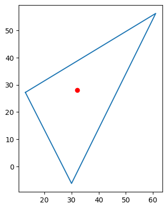

```python
# plot the Polygon and Point objects together
import matplotlib.pyplot as plt
fig, ax = plt.subplots()
ax.set_aspect('equal')
ax.plot(*poly1.exterior.xy)
ax.plot(new_point.x, new_point.y, 'o', color='red')
plt.show()
```

```python
poly1.contains(new_point)
```

```
True
```

Create a new point that is outside the polygon boundary.

```python
new_point2 = Point(25, 45)
```

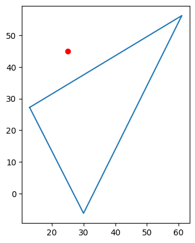

```python
# plot the Polygon and Point objects together
fig, ax = plt.subplots()
ax.set_aspect('equal')
ax.plot(*poly1.exterior.xy)
ax.plot(new_point2.x, new_point2.y, 'o', color='red')
plt.show()
```

```python
poly1.contains(new_point2)
```

```
False
```

As expected, it says that this is out of the boundary of this polygon.

## 9. Within

This is similar to `contains` with the difference that it checks whether a object is within the boundary of another object.

```python
new_point.within(poly1)
```

```
True
```

```python
new_point2.within(poly1)
```

```
False
```

## 10. Crosses

As the name suggests, `crosses` allows us to see whether a geometry object (here, LineString) crosses another geometry object (here, a Polygon).

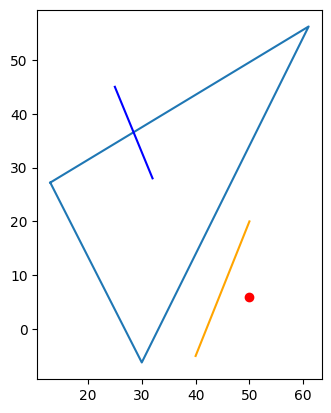

```python
from shapely.geometry import Point, Polygon, LineString
import matplotlib.pyplot as plt

# create multiple Point objects to be utilized for creating a Polygon object
p1 = Point(13, 27.21)
p2 = Point(61, 56.21)
p3 = Point(30, -6.21)
# use these points to create Polygon object
poly1 = Polygon([p1, p2, p3])

# create a Point object
point = Point(50, 6)

# create two LineString objects
line1 = LineString([(32, 28), (25, 45)])
line2 = LineString([(40, -5), (50, 20)])

# plot the Polygon, Point, and LineString objects together
fig, ax = plt.subplots()
ax.set_aspect('equal')
ax.plot(*poly1.exterior.xy)
ax.plot(point.x, point.y, 'o', color='red')
ax.plot(*line1.xy, color='blue')
ax.plot(*line2.xy, color='orange')
plt.show()
```

We see that `line1` or blue line crosses the polygon. How can we check this without checking visually? The answer is `crosses`.

```python
line1.crosses(poly1)
```

```
True
```

The result is as expected. Now, does the line `line2` with orange color crosses the polygon? We know it doesn't, let's check this by using `crosses` again.

```python
line2.crosses(poly1)
```

```
False
```

## 11. Difference

The `difference()` method is used to compute the difference between two geometric objects. When this method is called on a Polygon object, it returns a new Polygon object that represents the difference between the original Polygon object and another Polygon object passed as an argument to the `difference()` method.

```python
p1 = Point([20, 40])
```

```python
p2 = Point([40, 80])
```

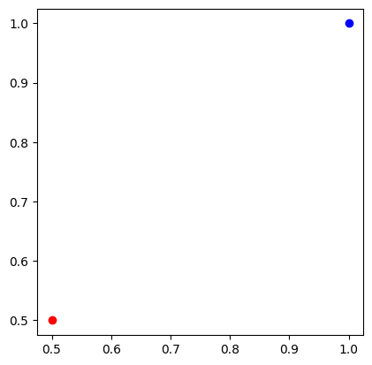

```python
from shapely.geometry import Point
import matplotlib.pyplot as plt

# create two Point objects
point1 = Point(0.5, 0.5)
point2 = Point(1, 1)

# plot the Point objects together
fig, ax = plt.subplots()
ax.set_aspect('equal')
ax.plot(point1.x, point1.y, 'o', color='red')
ax.plot(point2.x, point2.y, 'o', color='blue')
plt.show()
```

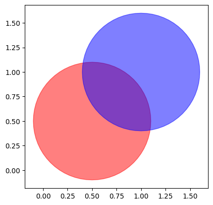

```python
from shapely.geometry import Point, Polygon
import matplotlib.pyplot as plt

# create two Point objects
point1 = Point(0.5, 0.5)
point2 = Point(1, 1)

# create Polygon objects with buffer zone around each point
buffer1 = point1.buffer(0.6)
buffer2 = point2.buffer(0.6)

# plot the Polygon objects with buffer zone
fig, ax = plt.subplots()
ax.set_aspect('equal')
ax.fill(*buffer1.exterior.xy, alpha=0.5, color='red')
ax.fill(*buffer2.exterior.xy, alpha=0.5, color='blue')
plt.show()
```

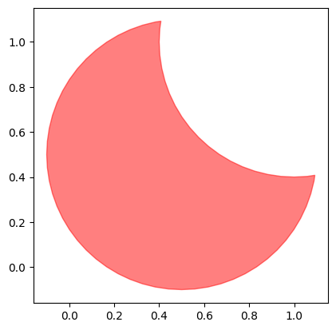

```python
result = buffer1.difference(buffer2)

import matplotlib.pyplot as plt
from shapely.geometry import Point

# plot the difference between buffer1 and buffer2
fig, ax = plt.subplots()
ax.set_aspect('equal')
# ax.axis('off')
ax.fill(*result.exterior.xy, alpha=0.5, color='red')
plt.show()
```

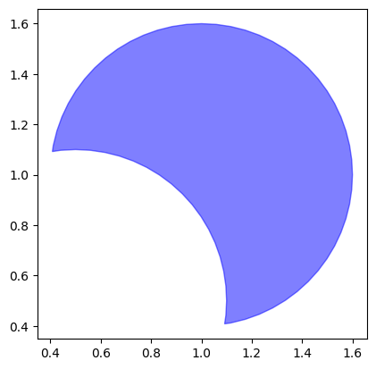

```python
result2 = buffer2.difference(buffer1)

import matplotlib.pyplot as plt
from shapely.geometry import Point

# plot the difference between buffer2 and buffer1
fig, ax = plt.subplots()
ax.set_aspect('equal')
# ax.axis('off')
ax.fill(*result2.exterior.xy, alpha=0.5, color='blue')
plt.show()
```

## 12. Intersection

`intersection` is used to obtain the region where two or more geometries overlap. When we apply the `intersection` method to two geometries, the resulting geometry is a new geometry that represents the region where the two original geometries overlap. The intersection method can be applied to any type of geometry, including Points, Lines, and Polygons.

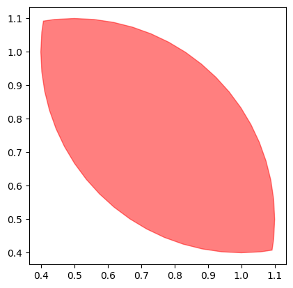

```python
intersection = buffer1.intersection(buffer2)

# plot the intersection between buffer1 and buffer2
fig, ax = plt.subplots()
ax.set_aspect('equal')
# ax.axis('off')
ax.fill(*intersection.exterior.xy, alpha=0.5, color='red')
plt.show()
```

## 13. Union

We use `union` to combine two or more geometries into a single geometry. When we apply the `union` method to two geometries, it results into new geometry that encompasses the area covered by both of the original geometries. We can use the `union` method with `Points`, `Lines`, and `Polygons`.

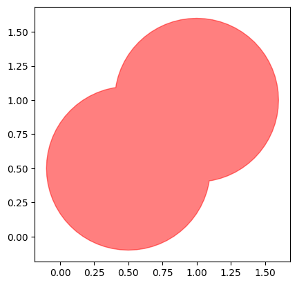

```python
union = buffer1.union(buffer2)

# plot the union of buffer1 and buffer2
fig, ax = plt.subplots()
ax.set_aspect('equal')
# ax.axis('off')
ax.fill(*union.exterior.xy, alpha=0.5, color='red')
plt.show()
```

## 14. Symmetric difference

The `symmetric_difference()` method in the Shapely library computes the symmetric difference between two geometric objects. It returns a new geometric object that represents the area of the geometries that do not overlap.

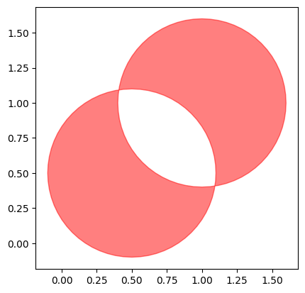

```python
union = buffer1.symmetric_difference(buffer2)

# plot the union of buffer1 and buffer2
fig, ax = plt.subplots()
ax.set_aspect('equal')
# ax.axis('off')
for polygon in union.geoms:
    ax.fill(*polygon.boundary.xy, alpha=0.5, color='red')
plt.show()
```

## 15. Plot a shapefile

We will be using GeoPandas which is basically a Pandas dataframe plus GeoSeries which is a column that contains vector geometry. These geometries are handled as Shapely object and thus the operations that we have already done for different Shapely object can also be applied to GeoPandas geometries.

First, download the shapefile from this link and upload it to your Google Drive. Dowload link: https://drive.google.com/drive/folders/1Z4XFVorvwiLVJ90Ph9fgbov2QHn4LJ09?usp=share_link

```python
from google.colab import drive
drive.mount('/content/drive')
```

```python
# Put the path to the shapefile in your Google Drive here
path = "/content/drive/MyDrive/Geospatial_Python/Data/"
```

```python
!pip install geopandas
```

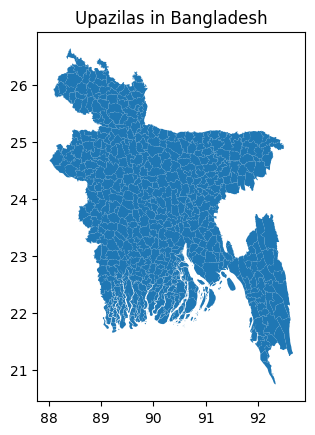

```python
import geopandas as gpd
import matplotlib.pyplot as plt

# Read the shapefile
bd = gpd.read_file(path+'BGD_adm3.shp')

# Plot the shapefile
bd.plot()

plt.title("Upazilas in Bangladesh")

# Show the plot
plt.show()
```

We can also zoom in to the northeast part of Bangladesh by using `cx` property of the GeoPandas dataframe. Here, we are specifying the range for latitude and longitude.

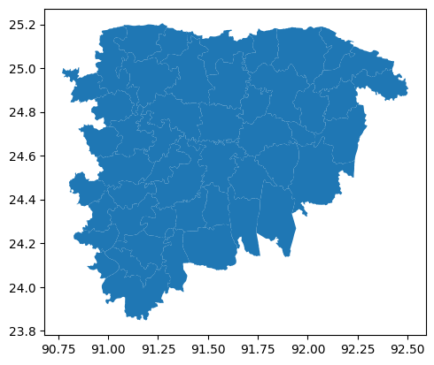

```python
bd.cx[91:92.5, 24:25.2].plot()
```

Let's have a look at the content of this GeoPandas dataframe.

```python
bd.head()
```

|  | ID_0 | ISO | NAME_0 | ID_1 | NAME_1 | ID_2 | NAME_2 | ID_3 | NAME_3 | TYPE_3 | ENGTYPE_3 | NL_NAME_3 | VARNAME_3 | geometry |
| --- | --- | --- | --- | --- | --- | --- | --- | --- | --- | --- | --- | --- | --- | --- |
| 0 | 20 | BGD | Bangladesh | 1 | Barisal | 1 | Barisal | 1 | Agailjhara | Upazila\|Thana\|Po | Sub-district | NaN | NaN | POLYGON ((90.13228 23.02925, 90.13877 23.03056... |
| 1 | 20 | BGD | Bangladesh | 1 | Barisal | 1 | Barisal | 2 | Babuganj | Upazila\|Thana\|Po | Sub-district | NaN | NaN | POLYGON ((90.27067 22.73984, 90.26520 22.74118... |
| 2 | 20 | BGD | Bangladesh | 1 | Barisal | 1 | Barisal | 3 | Bakerganj | Upazila\|Thana\|Po | Sub-district | NaN | NaN | MULTIPOLYGON (((90.35285 22.61147, 90.35315 22... |
| 3 | 20 | BGD | Bangladesh | 1 | Barisal | 1 | Barisal | 4 | Banaripara | Upazila\|Thana\|Po | Sub-district | NaN | NaN | POLYGON ((90.19837 22.78146, 90.19374 22.78425... |
| 4 | 20 | BGD | Bangladesh | 1 | Barisal | 1 | Barisal | 5 | Barisal S. | Upazila\|Thana\|Po | Sub-district | NaN | NaN | MULTIPOLYGON (((90.31945 22.66389, 90.31913 22... |

In the field of GIS, the columns are called attributes. Column `NAME_1` represents the name of the divisions, column `NAME_2` represents the name of the districts, and column `NAME_3` represents the name of the upazilas.

Now, we can get the data (and map) of any division, district or upazila by using dataframe subsetting.

```python
# Get the data for Dhaka division and map it
dhaka = bd[bd['NAME_1'] == 'Dhaka']
```

```python
dhaka.head()
```

|  | ID_0 | ISO | NAME_0 | ID_1 | NAME_1 | ID_2 | NAME_2 | ID_3 | NAME_3 | TYPE_3 | ENGTYPE_3 | NL_NAME_3 | VARNAME_3 | geometry |
| --- | --- | --- | --- | --- | --- | --- | --- | --- | --- | --- | --- | --- | --- | --- |
| 126 | 20 | BGD | Bangladesh | 3 | Dhaka | 18 | Dhaka | 127 | Dhamrai | Upazila\|Thana\|Po | Sub-district | NaN | NaN | POLYGON ((90.12955 23.87060, 90.12621 23.87337... |
| 127 | 20 | BGD | Bangladesh | 3 | Dhaka | 18 | Dhaka | 128 | Dohar | Upazila\|Thana\|Po | Sub-district | NaN | NaN | POLYGON ((90.20849 23.56972, 90.20309 23.56527... |
| 128 | 20 | BGD | Bangladesh | 3 | Dhaka | 18 | Dhaka | 129 | Keraniganj | Upazila\|Thana\|Po | Sub-district | NaN | NaN | POLYGON ((90.34762 23.74652, 90.35153 23.74214... |
| 129 | 20 | BGD | Bangladesh | 3 | Dhaka | 18 | Dhaka | 130 | Nawabganj | Upazila\|Thana\|Po | Sub-district | NaN | Dhaka | POLYGON ((90.05322 23.62834, 90.04811 23.62989... |
| 130 | 20 | BGD | Bangladesh | 3 | Dhaka | 18 | Dhaka | 131 | Savar | Upazila\|Thana\|Po | Sub-district | NaN | NaN | POLYGON ((90.24256 23.78172, 90.24339 23.78748... |

We can see that now we have data for Dhaka division only (note the values of `NAME_1` column or attribute).

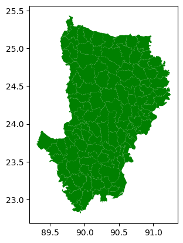

```python
dhaka.plot(color='green')
```

So, can we make a map of Rajshahi district? We can, by considering the field 'NAME_2' field corresponding to district name.

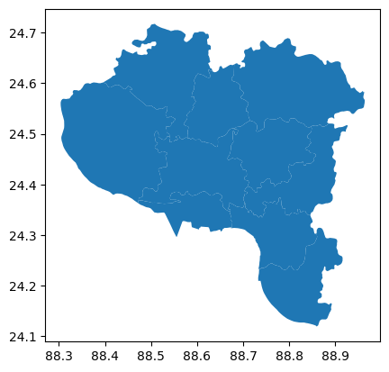

```python
rajshahi = bd[bd['NAME_2'] == 'Rajshahi']
rajshahi.plot()
```

Now, we will find out how many upazilas are in Sylhet division.

```python
sylhet_div = bd[bd['NAME_1'] == 'Sylhet'] # NAME_1 corresponds to division name
```

```python
sylhet_div.head()
```

|  | ID_0 | ISO | NAME_0 | ID_1 | NAME_1 | ID_2 | NAME_2 | ID_3 | NAME_3 | TYPE_3 | ENGTYPE_3 | NL_NAME_3 | VARNAME_3 | geometry |
| --- | --- | --- | --- | --- | --- | --- | --- | --- | --- | --- | --- | --- | --- | --- |
| 428 | 20 | BGD | Bangladesh | 7 | Sylhet | 62 | Hobiganj | 429 | Ajmiriganj | Upazila\|Thana\|Po | Sub-district | NaN | NaN | POLYGON ((91.23438 24.56620, 91.23683 24.57435... |
| 429 | 20 | BGD | Bangladesh | 7 | Sylhet | 62 | Hobiganj | 430 | Bahubal | Upazila\|Thana\|Po | Sub-district | NaN | NaN | POLYGON ((91.48452 24.27334, 91.48559 24.27835... |
| 430 | 20 | BGD | Bangladesh | 7 | Sylhet | 62 | Hobiganj | 431 | Baniachong | Upazila\|Thana\|Po | Sub-district | NaN | NaN | POLYGON ((91.21724 24.42625, 91.22263 24.42789... |
| 431 | 20 | BGD | Bangladesh | 7 | Sylhet | 62 | Hobiganj | 432 | Chunarughat | Upazila\|Thana\|Po | Sub-district | NaN | NaN | POLYGON ((91.41032 24.11111, 91.40565 24.11828... |
| 432 | 20 | BGD | Bangladesh | 7 | Sylhet | 62 | Hobiganj | 433 | Habiganj S. | Upazila\|Thana\|Po | Sub-district | NaN | NaN | POLYGON ((91.33085 24.27030, 91.33200 24.27221... |

```python
# Names of the upazilas
sylhet_div['NAME_3'].unique() # NAME_3 corresponds to upazila name
```

```
array(['Ajmiriganj', 'Bahubal', 'Baniachong', 'Chunarughat',
       'Habiganj S.', 'Lakhai', 'Madhabpur', 'Nabiganj', 'Barlekha',
       'Kamalganj', 'Kulaura', 'Maulvibazar S.', 'Rajnagar', 'Sreemangal',
       'Bishwamvarpur', 'Chhatak', 'Derai', 'Dharampasha', 'Dowarabazar',
       'Jagannathpur', 'Jamalganj', 'Sullah', 'Sunamganj S.', 'Tahirpur',
       'Balaganj', 'Beanibazar', 'Bishwanath', 'Companiganj',
       'Fenchuganj', 'Golabganj', 'Gowainghat', 'Jaintiapur', 'Kanaighat',
       'Sylhet S.', 'Zakiganj'], dtype=object)
```

```python
# Number of upazila
len(sylhet_div['NAME_3'].unique())
```

```
35
```

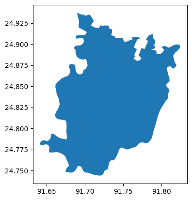

```python
# Let's plot Bishwanath upazila
bishwanath = sylhet_div[sylhet_div['NAME_3'] == 'Bishwanath'] # subset the data to have data for Bishwanath upazila only
bishwanath.plot()
```

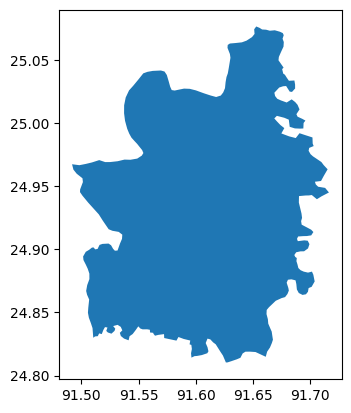

```python
# Let's plot Chhatak upazila under Sylhet division
sylhet_div[sylhet_div['NAME_3'] == 'Chhatak'].plot()
```

## 16. Add basemap

We can use `contextily` package for adding basemaps.

```python
!pip install contextily
```

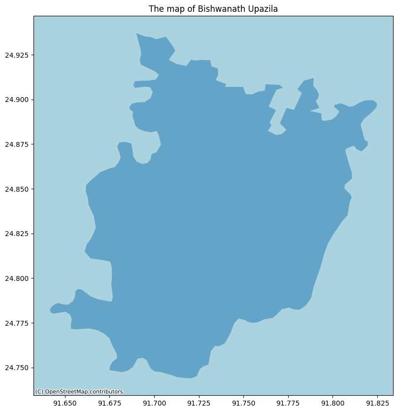

```python
import geopandas as gpd
import matplotlib.pyplot as plt
import contextily as ctx

# Set the figure size
fig, ax = plt.subplots(figsize=(10, 10))

# Plot the shapefile
bishwanath.plot(ax=ax, alpha=0.5)

# Add a basemap using contextily
ctx.add_basemap(ax=ax, source=ctx.providers.OpenStreetMap.Mapnik)

plt.title("The map of Bishwanath Upazila")

# Show the plot
plt.show()
```

We see that the OpenStreetMap is not displayed. This is because the CRS (Coordinate Reference System) of bishwanath GeoPandas dataframe and Openstreet Map are not the same. So, we need to put them to the same CRS and then plot.

[figure not shown]

```python
import geopandas as gpd
import matplotlib.pyplot as plt
import contextily as ctx

# Set the figure size
fig, ax = plt.subplots(figsize=(10, 10))

bishwanath = bishwanath.to_crs(epsg=3857)

# Plot the shapefile
bishwanath.plot(ax=ax, alpha=0.5)

# Add a basemap using contextily
ctx.add_basemap(ax=ax, source=ctx.providers.OpenStreetMap.Mapnik)

plt.title("The map of Bishwanath Upazila")

# Show the plot
plt.show()
```

```
# Set the figure size
fig, ax = plt.subplots(figsize=(10, 10))
```

The above line creates a matplotlib figure and axis with a specified size of 10 inches by 10 inches.

```
bishwanath = bishwanath.to_crs(epsg=3857)
```

This line converts the coordinate reference system (CRS) of the `bishwanath` GeoPandas dataframe to EPSG 3857, which is the CRS used by many online basemaps including OpenStreetMap. This ensures that the shapefile and basemap will be properly aligned.

```
# Plot the shapefile
bishwanath.plot(ax=ax, alpha=0.5)
```

This line plots the `bishwanath` shapefile on the `ax` axis with an alpha value of 0.5, making the shapefile semi-transparent.

```
# Add a basemap using contextily
ctx.add_basemap(ax=ax, source=ctx.providers.OpenStreetMap.Mapnik)
```

This line adds a basemap to the plot using `contextily`. We pass the `ax` axis as an argument and specify the `OpenStreetMap.Mapnik` provider as the source of the basemap.

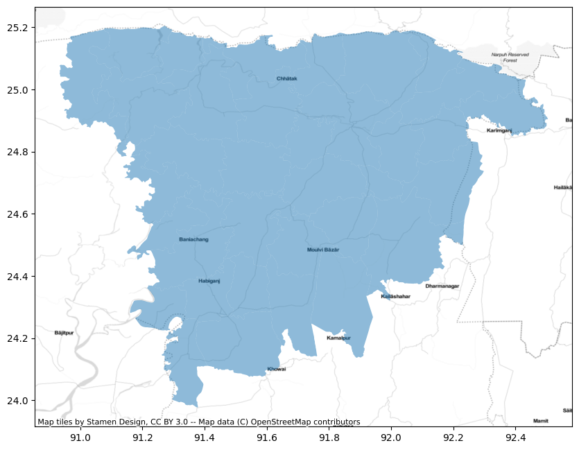

```python
%matplotlib inline

# Set the figure size
fig, ax = plt.subplots(figsize=(10, 10))

# Plot the shapefile
sylhet_div.plot(ax=ax, alpha=0.5)

# Add a basemap using contextily
ctx.add_basemap(ax=ax, crs=sylhet_div.crs.to_string(), source=ctx.providers.Stamen.TonerLite)

# Show the plot
plt.show()
```

## 18. Plotting raster data

Here, we will now read different bands of Landsat and plot these.

[output not shown]

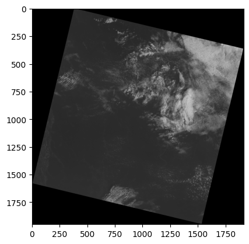

```python
import rasterio
from rasterio.plot import show
import matplotlib.pyplot as plt

# Open the TIF file
with rasterio.open(path+'LC08_L1TP_137043_20180410_20180417_01_T1_B1.tif') as src:
    # Read the data
    data = src.read()
    # Visualize the data
    show(data)
```

## 19. Color composite -- plotting multiple bands at the same time

[output not shown]

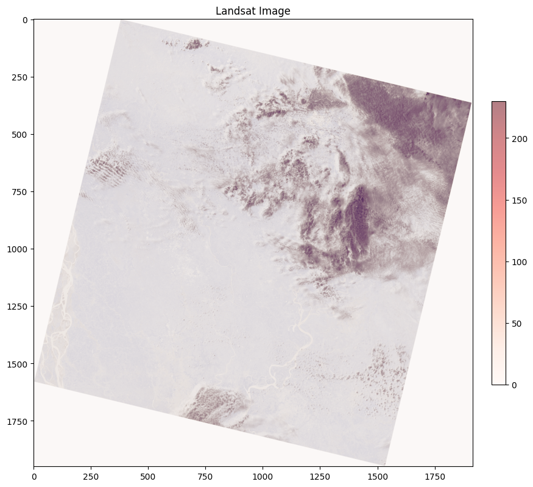

```python
import rasterio
from rasterio.plot import show
import matplotlib.pyplot as plt

# Open the TIF files for the 5 bands
band1 = rasterio.open(path+'LC08_L1TP_137043_20180410_20180417_01_T1_B1.tif')
band2 = rasterio.open(path+'LC08_L1TP_137043_20180410_20180417_01_T1_B2.tif')
band3 = rasterio.open(path+'LC08_L1TP_137043_20180410_20180417_01_T1_B3.tif')
band4 = rasterio.open(path+'LC08_L1TP_137043_20180410_20180417_01_T1_B4.tif')
band5 = rasterio.open(path+'LC08_L1TP_137043_20180410_20180417_01_T1_B5.tif')

# Read the data for each band
data1 = band1.read(1)
data2 = band2.read(1)
data3 = band3.read(1)
data4 = band4.read(1)
data5 = band5.read(1)

# Create a figure and axis object
fig, ax = plt.subplots(figsize=(10,10))

# Plot the 5 bands in the same plot
im1 = ax.imshow(data1, cmap='Reds', alpha=0.5)
im2 = ax.imshow(data2, cmap='Greens', alpha=0.5)
im3 = ax.imshow(data3, cmap='Blues', alpha=0.5)
im4 = ax.imshow(data4, cmap='Oranges', alpha=0.5)
im5 = ax.imshow(data5, cmap='Purples', alpha=0.5)

# Add a colorbar and title
fig.colorbar(im1, ax=ax, fraction=0.03, pad=0.04)
ax.set_title('Landsat Image')

# Show the plot
plt.show()
```

First, the code imports the necessary libraries: rasterio for reading the Landsat data and matplotlib for plotting the data.

```
import rasterio
import numpy as np
import matplotlib.pyplot as plt
```

Next, the code opens the TIF files for each band of the Landsat data using the `rasterio.open()` function:

```
band1 = rasterio.open('path/to/band1.tif')
band2 = rasterio.open('path/to/band2.tif')
band3 = rasterio.open('path/to/band3.tif')
band4 = rasterio.open('path/to/band4.tif')
band5 = rasterio.open('path/to/band5.tif')
```

The `open()` function returns a rasterio dataset object that can be used to read the data from the file.

To read the data for each band, the code uses the `read()` function of the rasterio dataset object:

```
data1 = band1.read(1)
data2 = band2.read(1)
data3 = band3.read(1)
data4 = band4.read(1)
data5 = band5.read(1)
```

The `read()` function returns a numpy array that contains the data for the band. The 1 argument specifies that we want to read the first band of the dataset.

Next, the code creates a figure and axis object using the `subplots()` function of the matplotlib library:

```
fig, ax = plt.subplots(figsize=(10,10))
```

The `figsize` parameter specifies the size of the figure in inches.

To plot the 5 bands in the same plot, the code uses the `imshow()` function of the matplotlib library:

```
im1 = ax.imshow(data1, cmap='Reds', alpha=0.5)
im2 = ax.imshow(data2, cmap='Greens', alpha=0.5)
im3 = ax.imshow(data3, cmap='Blues', alpha=0.5)
im4 = ax.imshow(data4, cmap='Oranges', alpha=0.5)
im5 = ax.imshow(data5, cmap='Purples', alpha=0.5)
```

The `imshow()` function displays an image on the axis. The `cmap` parameter specifies the colormap to use, and the `alpha` parameter specifies the transparency of the image.

To add a colorbar to the plot, the code uses the `colorbar()` function of the matplotlib library:

```
fig.colorbar(im1, ax=ax, fraction=0.03, pad=0.04)
```

The `colorbar()` function adds a colorbar to the figure. The `im1` argument specifies the image object that the colorbar should be based on. The `ax` parameter specifies the axis object that the colorbar should be added to. The `fraction` parameter specifies the fraction of the axis height that the colorbar should occupy, and the `pad` parameter specifies the space between the axis and the colorbar.

Finally, the code sets the title of the plot using the `set_title()` function of the axis object:

```
ax.set_title('Landsat Image')
```

And it shows the plot using the `show()` function of the matplotlib library:

```
plt.show()
```

## 20. Calculate NDVI (Normalized Difference Vegetation Index)

The formula for calculating NDVI is:

NDVI = (NIR - Red) / (NIR + Red)

where NIR is the near-infrared band and Red is the red band of the Landsat data.

In case of Landsat, band5 is NIR and band4 is Red or red band.

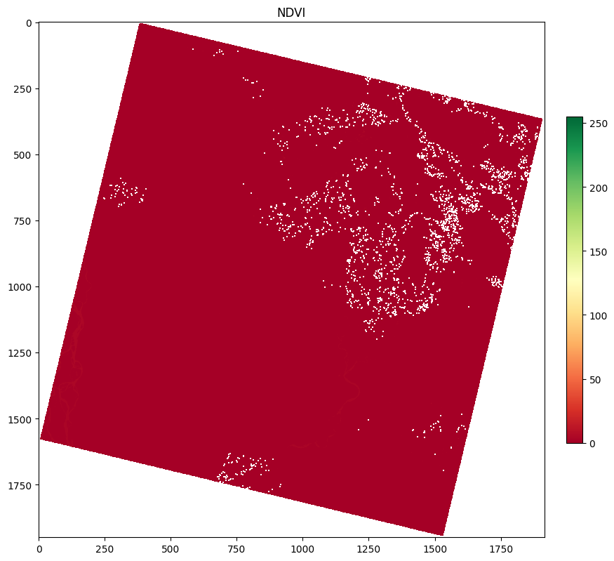

```python
# Calculate NDVI
ndvi = (data5 - data4) / (data5 + data4)

# Create a figure and axis object
fig, ax = plt.subplots(figsize=(10, 10))

# Plot the NDVI data
im = ax.imshow(ndvi, cmap='RdYlGn')

# Add a colorbar to the plot
fig.colorbar(im, ax=ax, fraction=0.03, pad=0.04)

# Set the title of the plot
ax.set_title('NDVI')

# Show the plot
plt.show()
```

## **References**

GeoPandas https://geopandas.org/en/stable/

Shapely https://shapely.readthedocs.io/en/stable/manual.html

Rasterio https://rasterio.readthedocs.io/en/stable/